# SOCI 30005_PS1_Hinojosa

## Expectation

> We are again going to work with NALS, now using three variables: parent years of education (X), respondent years of education (Z), and adult literacy (Y).

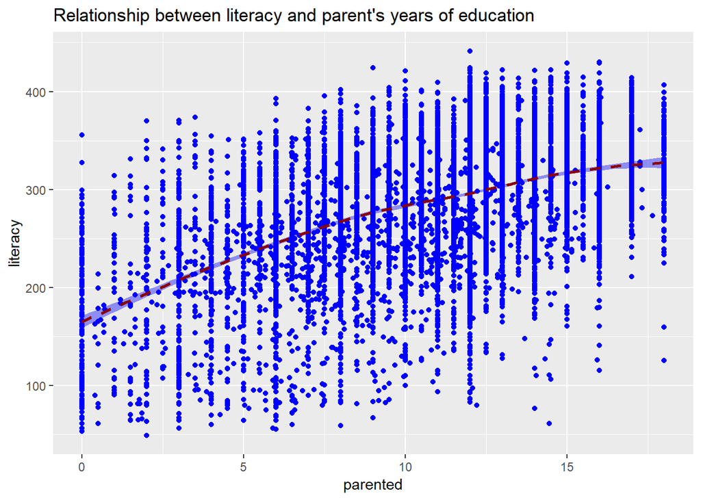

```r
# Relationship between literacy and parental years of education
ggplot(nals, aes(parented,literacy)) + geom_point(color="blue") +
  labs(title="Relationship between literacy and parent's years of education") +
  geom_smooth(method="loess", linetype="dashed",color="darkred", fill="blue")
```

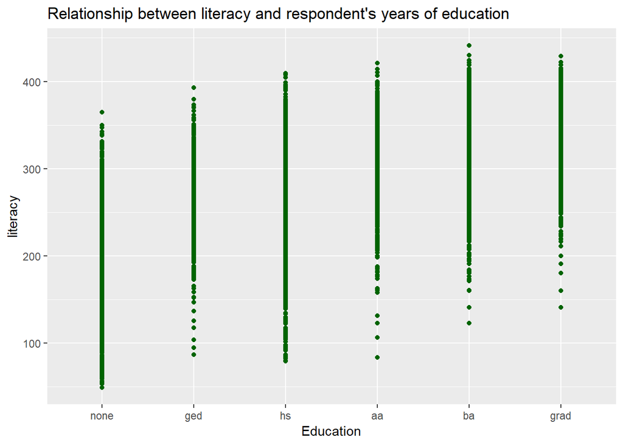

```r
# Relationship between literacy and respondent's education
ggplot(nals, aes(Education,literacy)) + geom_point(color="darkgreen") +
  labs(title="Relationship between literacy and respondent's years of education") +
  geom_smooth(method="loess", linetype="dashed",color="darkred", fill="green")
```

There is a general positive linear relationships between the outcome variable, respondent’s literacy level, with both of the independent variables, parent’s years of education and respondent’s educational attainment. There also doesn’t seem to be any extreme outliners that stand out, so we can continue examining for statistically significant linear relationships through regression models.

### Q1. Write down a theoretical linear regression model in which Y is a function of X and Z. Define the terms in the model. We will assume this is the true model" of the relationship between X,Z, and Y.

$\text{Y as a function of X and Z:}$
$$Y_i=\alpha+\beta X_i+\gamma Z_i+\varepsilon_i, \\
\varepsilon_i ~ N(0,\sigma_{y|x,z})$$
In the above model, $Y_i$ is the literacy level of a particular individual in the population, $\alpha$ is the y-intercept parameter for the model’s regression line, meaning that it is the average literacy level for an individual who has no educational degree ($\gamma Z_i$) and parents who have 0 years of education ($\beta X_i$). ($\beta_1 x$) is the regression coefficient for the slope parameter for parental education and ($\gamma Z_i$) is the parameter for respondent’s educational attainment. $\varepsilon_i$ is the difference between an individual’s actual literacy level and the average literacy level for all individuals in the population who share the same values in regards to their educational attainment, Z, and their parent’s years of education, X. $\sigma_{y|x,z}$ is the standard deviation for a particular subset of individuals in the populations with the same values for Z and X.

### Q2. Write down two other linear regression models: a) Z is a function of X; and b) X is a function of Z;

$\text{Z as a function of X:}$
$$Z_i=\alpha+\beta X_i+\varepsilon_i, \\
\varepsilon_i ~ N(0,\sigma_{z|x})$$

$\text{X as a function of Z:}$
$$X_i=\alpha+\beta Z_i+\varepsilon_i, \\
\varepsilon_i ~ N(0,\sigma_{x|z})$$

### Q3. Now suppose someone estimated a model using only Z as a predictor. That means the person would be studying the expected value of Y given Z alone.

#### a. Using (1), find E(Y|Z).

$$\mathbb E(Y|Z)=\mathbb E(\alpha) + \mathbb E(\beta Z)$$

#### b. Using (1) and (2b), define the bias involved. Show that it has two parts and define them.

$$\begin{aligned}
Y_i=\alpha+\beta Z_i+\varepsilon_i \\
\beta=Z_i+\gamma(Z_i)+\varepsilon_i\\
\end{aligned}$$
In the above model, $\beta=Z_i$ is the naive estimate of the coefficient for the respondent’s educational attainment as a sole predictor of their literacy level, $Y_i$. The potential bias in the model is captured by $\gamma(Z_i)+\varepsilon_i$. The two conditions for bias to equal 0 is for $\gamma=0$ or if there was no difference in the predicted average literacy level between individuals with varying years of education.

```r
# linear regression of respondent's educational attainment on adult literacy
lm_literacy_ed <- lm(nals$literacy ~ nals$Education)
summary(lm_literacy_ed)
```

```
##
## Call:
## lm(formula = nals$literacy ~ nals$Education)
##
## Residuals:
##      Min       1Q   Median       3Q      Max
## -219.725  -27.976    3.964   33.882  160.501
##
## Coefficients:
##                    Estimate Std. Error t value Pr(>|t|)
## (Intercept)         204.398      1.221  167.38   <2e-16 ***
## nals$Educationged    65.202      2.522   25.86   <2e-16 ***
## nals$Educationhs     74.697      1.387   53.84   <2e-16 ***
## nals$Educationaa     98.976      1.721   57.50   <2e-16 ***
## nals$Educationba    120.800      1.594   75.78   <2e-16 ***
## nals$Educationgrad  131.235      1.848   71.01   <2e-16 ***
## ---
## Signif. codes:  0 '***' 0.001 '**' 0.01 '*' 0.05 '.' 0.1 ' ' 1
##
## Residual standard error: 48.39 on 12486 degrees of freedom
## Multiple R-squared:  0.3777, Adjusted R-squared:  0.3775
## F-statistic:  1516 on 5 and 12486 DF,  p-value: < 2.2e-16
```

```r
stargazer(lm_literacy_ed, type='text')
```

```
##
## ================================================
##                         Dependent variable:
##                     ----------------------------
##                               literacy
## ------------------------------------------------
## Educationged                 65.202***
##                               (2.522)
##
## Educationhs                  74.697***
##                               (1.387)
##
## Educationaa                  98.976***
##                               (1.721)
##
## Educationba                  120.800***
##                               (1.594)
##
## Educationgrad                131.235***
##                               (1.848)
##
## Constant                     204.398***
##                               (1.221)
##
## ------------------------------------------------
## Observations                   12,492
## R2                             0.378
## Adjusted R2                    0.377
## Residual Std. Error     48.388 (df = 12486)
## F Statistic         1,515.971*** (df = 5; 12486)
## ================================================
## Note:                *p<0.1; **p<0.05; ***p<0.01
```

```r
lm_yz.ged <- 65.202
lm_yz.hs <- 74.697
lm_yz.aa <- 98.976
lm_yz.ba <- 120.800
lm_yz.grad <- 131.235
```

In a linear regression of respondent educational on adult literacy, the coefficients vary by level of educational attainment. The model predicts an average literacy score increase of 65.2 for respondents with a ged, 74.7 for those with a high school degree, 99 for those with an associates degree, 120.8 for those with a bachelor’s degree, and 131.2 for respondents with a master’s degree or higher. Respondents with no educational degree having a predicted average literacy score of 204.4 under this model. All coefficient estimates are statistically significant (p<0.001***) and have large magnitudes. Having a GED is predicted to have the smallest estimated average effect on literacy scores compared to the other educational degrees, with a large t-score of 25.8.

$$y_i = 204.4 + z_{\text{no_degree}} + \epsilon \\
y_i = 204.4 + 65.2z_{ged} + \epsilon \\
y_i = 204.4 + 74.7z_{hs} + \epsilon \\
y_i = 204.4 + 98.98z_{aa} + \epsilon \\
y_i = 204.4 + 120.8z_{ba} + \epsilon \\
y_i = 204.4 + 131.24z_{grad} + \epsilon \\$$

### Q4. Now suppose someone estimated a model using only X as a predictor. That means this person would be studying the expected value of Y given X alone (2c).

#### a. Using (1), find E(Y|X). Define the “total effect” of X on Y.

$$\mathbb E(Y|X)=\mathbb E(\alpha) + \mathbb E(\beta X)$$
$\text{Total effect of parent education (X) on adult literacy (Y):}$
$$\begin{aligned}
Y_i=\alpha+\beta X_i+\varepsilon_i \\
\beta=X_i+\gamma(X_i)+\varepsilon_i\\
\end{aligned}$$
#### b. What is the direct effect of X on Y based on your theoretical model (1)?

### Q5. Estimate these total, direct, and indirect effects using NALS, and comment on what you have learned about how parent education and respondent education are linked to adult literacy.

```r
# linear regression of parental education (X) on adult literacy (Y)
lm_yx <- lm(nals$literacy ~ nals$parented)
summary(lm_yx)
```

```
##
## Call:
## lm(formula = nals$literacy ~ nals$parented)
##
## Residuals:
##      Min       1Q   Median       3Q      Max
## -254.977  -30.513    4.537   36.879  163.180
##
## Coefficients:
##               Estimate Std. Error t value Pr(>|t|)
## (Intercept)   192.4736     1.5413  124.88   <2e-16 ***
## nals$parented   8.5697     0.1341   63.92   <2e-16 ***
## ---
## Signif. codes:  0 '***' 0.001 '**' 0.01 '*' 0.05 '.' 0.1 ' ' 1
##
## Residual standard error: 53.24 on 12490 degrees of freedom
## Multiple R-squared:  0.2465, Adjusted R-squared:  0.2465
## F-statistic:  4086 on 1 and 12490 DF,  p-value: < 2.2e-16
```

```r
stargazer(lm_yx, type='text')
```

```
##
## ================================================
##                         Dependent variable:
##                     ----------------------------
##                               literacy
## ------------------------------------------------
## parented                      8.570***
##                               (0.134)
##
## Constant                     192.474***
##                               (1.541)
##
## ------------------------------------------------
## Observations                   12,492
## R2                             0.247
## Adjusted R2                    0.246
## Residual Std. Error     53.238 (df = 12490)
## F Statistic         4,086.296*** (df = 1; 12490)
## ================================================
## Note:                *p<0.1; **p<0.05; ***p<0.01
```

```r
direct_yx <- 8.5697
direct_yx
```

```
## [1] 8.5697
```

$$\begin{aligned}
Y_i&=\alpha+\beta X_i+\varepsilon_i \\
y_i&= 192.47 + 8.57x + e
\end{aligned}$$
In a linear regression of parental education on adult literacy, parental education has a significant total effect on literacy with a coefficient of $b=$8.57(.134), $t=63.92$, $p<0.001***$. This means that the model estimates an average increase of 8.57 units in a respondent’s literacy level for every added 1 year of parental education, with respondents with 0 years of parental edcuation having a predicted average literacy score of 192.47.

$\text{Indirect effect of parent education (X) on educational attainment (Z):}$

```r
# linear regression of parental education (X) on educational attainment (Z)
lm_xz <- lm(parented ~ Education, data=nals)
summary(lm_xz)
```

```
##
## Call:
## lm(formula = parented ~ Education, data = nals)
##
## Residuals:
##      Min       1Q   Median       3Q      Max
## -12.8086  -1.8085   0.2704   1.9622  10.5471
##
## Coefficients:
##               Estimate Std. Error t value Pr(>|t|)
## (Intercept)    7.45287    0.07946   93.79   <2e-16 ***
## Educationged   2.50642    0.16408   15.28   <2e-16 ***
## Educationhs    3.08494    0.09027   34.17   <2e-16 ***
## Educationaa    4.55388    0.11200   40.66   <2e-16 ***
## Educationba    5.35568    0.10372   51.64   <2e-16 ***
## Educationgrad  5.27675    0.12025   43.88   <2e-16 ***
## ---
## Signif. codes:  0 '***' 0.001 '**' 0.01 '*' 0.05 '.' 0.1 ' ' 1
##
## Residual standard error: 3.149 on 12486 degrees of freedom
## Multiple R-squared:  0.2151, Adjusted R-squared:  0.2148
## F-statistic: 684.4 on 5 and 12486 DF,  p-value: < 2.2e-16
```

```r
stargazer(lm_xz, type='text')
```

```
##
## ===============================================
##                         Dependent variable:
##                     ---------------------------
##                              parented
## -----------------------------------------------
## Educationged                 2.506***
##                               (0.164)
##
## Educationhs                  3.085***
##                               (0.090)
##
## Educationaa                  4.554***
##                               (0.112)
##
## Educationba                  5.356***
##                               (0.104)
##
## Educationgrad                5.277***
##                               (0.120)
##
## Constant                     7.453***
##                               (0.079)
##
## -----------------------------------------------
## Observations                  12,492
## R2                             0.215
## Adjusted R2                    0.215
## Residual Std. Error     3.149 (df = 12486)
## F Statistic         684.446*** (df = 5; 12486)
## ===============================================
## Note:               *p<0.1; **p<0.05; ***p<0.01
```

```r
ind_xz.ged <- 2.50642
ind_xz.hs <- 3.08494
ind_xz.aa <- 4.55388
ind_xz.ba <- 5.35568
ind_xz.grad <- 5.27675
```

$$y=\delta z + \beta x+e$$